[figure not shown]

# Advanced Graphics and Data Visualization in R

# Lecture 06: Trees, Network Diagrams and Genomic Representations

## 0.1.0 An overview of Advanced Graphics and Data Visualization in R

**"Advanced Graphics and Data Visualization in R"** is brought to you by the Centre for the Analysis of Genome Evolution & Function's (CAGEF) bioinformatics training initiative. This CSB1021 was developed to enhance the skills of students with basic backgrounds in R by focusing on available philosophies, methods, and packages for plotting scientific data. While the datasets and examples used in this course will be centred on SARS-CoV-2 epidemiological and genomic data, the lessons learned herein will be broadly applicable.

This lesson is the sixth and final lecture in a 6-part series. The aim for the end of this series is for students to recognize how to import, format, and display data based on their intended message and audience. The format and style of these visualizations will help to identify and convey the key message(s) from their experimental data.

The structure of the class is a **code-along style** in Jupyter notebooks. At the start of each lecture, skeleton versions of the lecture will be provided for use on the [University of Toronto Jupyter Hub](https://jupyter.utoronto.ca/hub/login) so students can program along with the instructor.

## 0.2.0 Lecture objectives

This week will focus on commonly used visualizations related to genomic information. When working with sequencing data, you may commonly wish to compare sequences based on their relationships or relative similarity (trees), by their sequence identity in gene families or potential interactions (graphs), and or more directly their sequence motifs.

At the end of this lecture you will have covered the following topics

1. Phylogenetic Trees
2. Network graphs
3. Genome sequences and markers

## 0.3.0 A legend for text format in Jupyter markdown

`grey background` - a package, function, code, command or directory. Backticks are also use for in-line code.  
*italics* - an important term or concept or an individual file or folder  
**bold** - heading or a term that is being defined  
blue text - named or unnamed hyperlink

`...` - Within each coding cell this will indicate an area of code that students will need to complete for the code cell to run correctly.

**Blue box:** A key concept that is being introduced

**Yellow box:** Risk or caution

**Green boxes:** Recommended reads and resources to learn Python

**Red boxes:** A comprehension question which may or may not involve a coding cell. You usually find these at the end of a section.

## 0.4.0 Data used in this lesson

Today's datasets will focus on SARS-CoV-2 variant surveillance data from the which has been tracking published sequenced genomes for the appearance of new strains in North America.

### 0.4.1 Dataset 1: nextstrain_ncov_north-america_canada_timetree.nwk

This is a Newick format data set describing a phylogenetic tree of SARS-CoV-2 strain information.

### 0.4.2 Dataset 2: nextstrain_ncov_north-america_canada_metadata.tsv

Metadata that accompanies the first dataset. It links strain information back to as much geographical and related information as possible.

## 0.5.0 Packages used in this lesson

`repr`- a package useful for altering some of the attributes of objects related to the R kernel.

`tidyverse` which has a number of packages including `dplyr`, `tidyr`, `stringr`, `forcats` and `ggplot2`

`viridis` helps to create color-blind palettes for our data visualizations

`RColorBrewer` has some hlepful palettes that we'll need to colour our data.

`ggnewscale` will be helpful in generating multiple colour palettes across increasingly complex plots.

`treeio`, `tidytree`, and `ggtree` will be used to help import, parse and plot phylogenetic trees.

`tidygraph` and `ggraph` will be used to generate network graph objects and plot them.

`ggseqlogo` is used for generating sequence logos related to sequence motifs.

`qqman` is a wrapper package for generating Manhattan plots.

`lubridate` and `zoo` help us to work with some date-based information.

```r
# When do we start installing the packages
Sys.time()

if (!requireNamespace("BiocManager", quietly = TRUE))
    install.packages("BiocManager")

# New packages we haven't worked with before
BiocManager::install("ggnewscale")
install.packages("tidytree")

# 230413: May need to do this to get an older version of ggtree to work
install.packages("https://cran.r-project.org/src/contrib/Archive/rvcheck/rvcheck_0.1.3.tar.gz", repos = NULL)
# Install treeio before installing ggtree
BiocManager::install("treeio")

library(remotes)
install_bioc("ggtree", upgrade = "never") # Do not try to update treeio. It won't work on Jupyter Hub

install_bioc("ggtreeExtra", upgrade = "never")

# BiocManager::install("ggtreeExtra", force = TRUE)
install.packages("ggseqlogo")
install.packages("qqman")

# When do we finish?
Sys.time()
```

```r
# Packages to help tidy our data
library(tidyverse)
library(readxl)

# Packages for the graphical analysis section
library(repr)
library(viridis)
library(RColorBrewer)
library(ggnewscale)

# Packages for today's lecture about trees
library(tidytree)
library(ggtree)
library(ggtreeExtra)
library(treeio)

# Packages for graphs
library(ggraph)
library(tidygraph)

# Packages for sequence logos
library(ggseqlogo)

# Packages for Manhattan plots
library(qqman)

# Date calculation helpers
library(lubridate)
library(zoo)
```

[output not shown]

[output cut: 9 more lines]

[output not shown]

# 1.0.0 What's in a name? A phylogenetic tree is just a rebranded dendrogram

Dendrograms, cladograms, and phylogenetic trees all share a similar structure with some modifications. All are represented in branching tree structures that are used to represent the relationships among the leaves, also known as **tips**. Branches along the tree may also be referred to as **edges**.

Leaves can represent different species, strains, or multi-dimensional values. Leaves are connected by branches to their nearest neighbours or relatives. As you move backwards along the tree, you encounter internal **nodes** which can connect directly to more tips or more nodes. The distance between tips and nodes represent a relative distance that may be defined as some type of evolutionary distance, time, or simple euclidean distance. In a cladogram, however, distances along branches have no meaning and only define the presence of a relationship.

In tree terminology, it is helpful to define a few more terms:

| Term | Description |
| --- | --- |
| **Root** | A tree is rooted when it defines a common ancester for all tips in the tree. This could be considered the start or entry point for the tree |
| **Most recent common ancester (MRCA)** | This is an internal node that collectively joins two or more tips. |
| **Clade** | A group of taxa (tips) that includes a common ancestor and *all* of its descendents. |
| **Scaling** | This indicates that the branch lengths *do* represent a distance metric, whereas, an unscaled tree may have even-length branches not representative of evolutionary/relationship distances. |

[output not shown]

## 1.1.0 Where does tree data come from?

As we saw last week, clustering analysis such as that from `hclust()` can create dendrogram data. We plotted this in a couple of ways by itself using `fviz_dend()` from the `factoextra` package and with `heatmap.2()` from the `gplots` package. In the case of our first foray, we were looking at the "relationships" between samples by indicating how similar they were based on the characteristics in their various features.

Depending on the software used, trees can be represented in a number of formats, some of which are described below.

| Format | Description |
| --- | --- |
| Newick | The standard used to represent trees in a computer-readable format. Trees are encoded in a parentheses-closure format where each tip takes the form of "**taxa:branch-length**" |
|  | and pairs of tips are separated by a comma `,` and enclosed by parentheses `()`. Internal nodes branch lengths are defined outside the parentheses with "**():branch-length**" |
| NEXUS/phylip | Incorporates the Newick tree with separate related data that is partitioned into different blocks. Blocks are started with "**BEGIN \<BLOCK NAME>;**" and closed with "**END;**" |
| NHX | New Hampshire eXtended format is also based on Newick format but instead of code blocks uses a tagging system for each node extending the format to |
|  | "**taxa:branch-length[&&NHX:<tag information>]**" |

## 1.2.0 Using `read.tree()` from the `treeio` package

When opening tree files, depending on the format, you can use the `treeio` package and one of it's many [parsing functions](https://yulab-smu.top/treedata-book/chapter1.html) but the simplest way to avoid figuring out how to open a tree file, is to just use the `read.tree()` function. This will determing the appropriate file type and parse through the many different tree formats before depositing the data into a `phylo` object.

Today we'll be working with a dataset from the [Auspice COVID-19 North American dataset](http://auspice.finlaymagui.re/ncov/north-america/canada/ontario) maintained by [Finlay Maguire](https://finlaymagui.re/). **Unfortunately this dataset is no longer available but we have an older copy with a fair amount of metadata.**

Let's begin by opening up the tree data and some related metadata before taking a look under the hood.

```r
# Import our Newick Tree
SC2_variants_time.phylo <- read.tree("data/nextstrain_ncov_north-america_canada_timetree.nwk")

# Import our metadata
SC2_metadata.df <- read_tsv("data/nextstrain_ncov_north-america_canada_metadata.tsv")
```

```r
# What does the tree look like?
str(SC2_variants_time.phylo)

SC2_variants_time.phylo
```

```
List of 6
 $ edge       : int [1:12776, 1:2] 6628 6628 6629 6630 6631 6630 6632 6632 6633 6629 ...
 $ edge.length: num [1:12776] 0.0757 0.0848 0.0336 0.0501 0 ...
 $ Nnode      : int 6150
 $ node.label : chr [1:6150] "NODE_0008606" "NODE_0000001" "NODE_0000061" "USA/MA1/2020_travel_history" ...
 $ tip.label  : chr [1:6627] "Wuhan/WH01/2019" "USA/MA1/2020" "Canada/ON_ON-VIDO-01-2/2020" "Canada/ON_VIDO-01/2020" ...
 $ root.edge  : num 2020
 - attr(*, "class")= chr "phylo"
 - attr(*, "order")= chr "cladewise"
```

```
Phylogenetic tree with 6627 tips and 6150 internal nodes.

Tip labels:
  Wuhan/WH01/2019, USA/MA1/2020, Canada/ON_ON-VIDO-01-2/2020, Canada/ON_VIDO-01/2020, USA/CA-CDC-5/2020, Taiwan/CGMH-CGU-02/2020, ...
Node labels:
  NODE_0008606, NODE_0000001, NODE_0000061, USA/MA1/2020_travel_history, NODE_0000062, Canada/ON_VIDO-01/2020_travel_history, ...

Rooted; includes branch lengths.
```

### 1.2.1 The `phylo` object is a simple list

From the looks of our structure, after reading in our Newick file, we have a list with six elements. They are pretty clearly named with edge information (a matrix of paired numbers), edge lengths, a count of the number of nodes (ie *internal* points where branches bifurcate. While mostly just numbers, some of these `node.label` values appear to be based on travel history information. All of the 6,627 `tip.label` values correspond to 6,627 SARS-CoV-2 strain names found in the metadata file as well.

### 1.2.2 Convert the tree object to a tibble for adding external information

Suppose we want to combine some information from our metadata with our tree? We can then use this information to colour, shape, and bring more visual order to our tree. Working with the tree, however, can be a little hard given that we have lists of different lengths representing different portions of the tree.

In our case, we only have tree tip information that we want to add to and the easiest way to work would be if it was in a table format. The package `tidytree` provides a function `as_tibble` that will parse and convert the `phylo` format to a `tbl_tree` object, which is a kind of tidy data frame.

Let's convert our variant phylo object to something we can work with.

```r
# Convert the phylo object using as_tibble
SC2_variants_time.tb <- as_tibble(SC2_variants_time.phylo)

# Check out the structure now
str(SC2_variants_time.tb)

head(SC2_variants_time.tb)
```

```
tbl_tree [12,777 x 4] (S3: tbl_tree/tbl_df/tbl/data.frame)
 $ parent       : int [1:12777] 6628 6631 6632 6633 6636 6635 6638 6638 6639 6640 ...
 $ node         : int [1:12777] 1 2 3 4 5 6 7 8 9 10 ...
 $ branch.length: num [1:12777] 0.0757 0 0.0077 0 0 ...
 $ label        : chr [1:12777] "Wuhan/WH01/2019" "USA/MA1/2020" "Canada/ON_ON-VIDO-01-2/2020" "Canada/ON_VIDO-01/2020" ...
```

A tbl_tree: 6 × 4

| parent <int> | node <int> | branch.length <dbl> | label <chr> |
| --- | --- | --- | --- |
| 6628 | 1 | 0.075652198 | Wuhan/WH01/2019 |
| 6631 | 2 | 0.000000000 | USA/MA1/2020 |
| 6632 | 3 | 0.007696891 | Canada/ON_ON-VIDO-01-2/2020 |
| 6633 | 4 | 0.000000000 | Canada/ON_VIDO-01/2020 |
| 6636 | 5 | 0.000000000 | USA/CA-CDC-5/2020 |
| 6635 | 6 | 0.044204648 | Taiwan/CGMH-CGU-02/2020 |

## 1.3.0 Updating our tree with external information

As you can see our `SC2_variants_time.tb` object is a simple data frame now represented as a 4-column table with 12,777 rows. The edge data is encoded between the `parent` and `node` columns with `branch.length` to define the length of each edge. We also have all of the tip and node names stored under the `label` column. With the tree in this format, we can now treat the tree like a tibble and join additional information to the tree.

Rules to keep in mind:

1. Don't lose any node information from your original tree structure. Losing "observations" is essentially losing edges of your tree!
2. Try to work with a complete dataset of information although sometimes it doesn't make sense that you would have it all.
3. Convert your tibble back to a tree format when you're done with `as.treedata()`

You may have information about the leaves or tips of your tree but by default there is no real internal node information when it comes to sample origins or lineage. When joining information to the tables, use the correct direction `*_join()` to avoid data loss. A `full_join()` is probably the safest.

Let's take a quick look at our metadata and identify what we're interested in.

```r
# Look at the metadata, which bits of information would be nice to add?
str(SC2_metadata.df, give.attr = FALSE)
```

```
spc_tbl_ [6,627 x 24] (S3: spec_tbl_df/tbl_df/tbl/data.frame)
 $ Strain                    : chr [1:6627] "Wuhan/WH01/2019" "USA/MA1/2020" "Canada/ON_ON-VIDO-01-2/2020" "Canada/ON_VIDO-01/2020" ...
 $ GISAID clade              : chr [1:6627] "L" "L" "L" "L" ...
 $ Nextstrain clade          : chr [1:6627] "19A" "19A" "19A" "19A" ...
 $ Age                       : num [1:6627] 44 21 NA NA 54 NA 47 47 23 55 ...
 $ Clade                     : chr [1:6627] "19A" "19A" "19A" "19A" ...
 $ Country                   : chr [1:6627] "Asia" "USA" "Canada" "Canada" ...
 $ Admin Division            : chr [1:6627] "Asia" "Massachusetts" "Ontario" "Ontario" ...
 $ Admin Division of exposure: chr [1:6627] "Asia" "Asia" "Ontario" "Asia" ...
 $ gisaid_epi_isl            : chr [1:6627] "EPI_ISL_406798" "EPI_ISL_409067" "EPI_ISL_425177" "EPI_ISL_413015" ...
 $ Host                      : chr [1:6627] "Human" "Human" "Human" "Human" ...
 $ Originating Lab           : chr [1:6627] "General Hospital of Central Theater Command of People's Liberation Army of China" "Massachusetts Department of Public Health" "Public Health Ontario" "Public Health Ontario Laboratory" ...
 $ PANGO lineage             : chr [1:6627] "B" "B" "B" "B" ...
 $ Submission Date           : chr [1:6627] "Older" "Older" "Older" "Older" ...
 $ Region                    : chr [1:6627] "Asia" "North America" "North America" "North America" ...
 $ Region of exposure        : chr [1:6627] "Asia" "Asia" "North America" "Asia" ...
 $ Sex                       : chr [1:6627] "Male" "Male" "Male" "Male" ...
 $ strain                    : chr [1:6627] "Wuhan/WH01/2019" "USA/MA1/2020" "Canada/ON_ON-VIDO-01-2/2020" "Canada/ON_VIDO-01/2020" ...
 $ Emerging Nextstrain clade : chr [1:6627] "19A" "19A" "19A" "19A" ...
 $ Submitting Lab            : chr [1:6627] "BGI & Institute of Microbiology, Chinese Academy of Sciences & Shandong First Medical University & Shandong Aca"| __truncated__ "Pathogen Discovery, Respiratory Viruses Branch, Division of Viral Diseases, Centers for Disease Control and Prevention" "Publi…
 $ url                       : logi [1:6627] NA NA NA NA NA NA ...
 $ Collection Data           : Date[1:6627], format: "2019-12-26" "2020-01-29" ...
 $ Author                    : chr [1:6627] "Weijun Chen et al (https://dx.doi.org/10.1016/S0140-6736(20)30251-8)" "Clinton R. Paden et al (https://dx.doi.org/10.1101/2020.03.09.20032896)" "Amrit S. Boese et al" "Shari Tyson et al" ...
 $ Country of exposure       : chr [1:6627] NA "Asia" NA "Asia" ...
 $ Location                  : chr [1:6627] NA "Boston" NA NA ...
```

```r
# Check out some of the values for these variables

# Metadata information on the samples
unique(SC2_metadata.df$Country)

unique(SC2_metadata.df$Age)

# Metadata information on the genomes
unique(SC2_metadata.df$'GISAID clade')

unique(SC2_metadata.df$'Nextstrain clade')

unique(SC2_metadata.df$Clade)

unique(SC2_metadata.df$'PANGO lineage')
```

1. 'Asia'

2. 'USA'

3. 'Canada'

4. 'Europe'

5. 'Guatemala'

6. 'Panama'

7. 'Africa'

8. 'Dominican Republic'

9. 'Costa Rica'

10. 'South America'

11. 'Oceania'

12. 'Jamaica'

13. 'Mexico'

14. 'Barbados'

15. 'Guadeloupe'

16. 'Saint Martin'

17. 'Bermuda'

18. 'Sint Maarten'

19. 'Saint Barthélemy'

20. 'Belize'

21. 'Saint Lucia'

22. 'El Salvador'

23. 'Cuba'

1. 44

2. 21

3. <NA>

4. 54

5. 47

6. 23

7. 55

8. 62

9. 49

10. 50

11. 43

12. 25

13. 26

14. 33

15. 38

16. 9

17. 73

18. 64

19. 57

20. 58

21. 0

22. 28

23. 70

24. 71

25. 20

26. 93

27. 36

28. 37

29. 40

30. 56

31. 89

32. 45

33. 34

34. 53

35. 94

36. 95

37. 86

38. 84

39. 60

40. 90

41. 27

42. 30

43. 59

44. 41

45. 46

46. 52

47. 51

48. 32

49. 24

50. 35

51. 29

52. 61

53. 79

54. 66

55. 78

56. 11

57. 2

58. 65

59. 75

60. 31

61. 48

62. 74

63. 68

64. 67

65. 63

66. 77

67. 42

68. 22

69. 12

70. 5

71. 17

72. 80

73. 16

74. 39

75. 82

76. 8

77. 7

78. 88

79. 76

80. 69

81. 19

82. 87

83. 3

84. 14

85. 18

86. 1

87. 81

88. 15

89. 6

90. 10

91. 85

92. 4

93. 98

94. 91

95. 72

96. 99

97. 13

98. 92

99. 83

100. 96

101. 104

1. 'L'

2. 'S'

3. 'O'

4. 'V'

5. 'GR'

6. 'G'

7. 'GV'

8. 'GH'

9. 'GRY'

10. NA

1. '19A'

2. '19B'

3. NA

4. '20A'

5. '20B'

6. '20E (EU1)'

7. '20A.EU2'

8. '20C'

9. '20G'

10. '20H/501Y.V2'

11. '20D'

12. '20J/501Y.V3'

13. '20F'

14. '20I/501Y.V1'

1. '19A'

2. '19B'

3. '20A'

4. '20E (EU1)'

5. '20C'

6. '20G'

7. '20H/501Y.V2'

8. '20B'

9. '20D'

10. '20J/501Y.V3'

11. '20F'

12. '20I/501Y.V1'

1. 'B'

2. 'A'

3. 'A.6'

4. 'A.2'

5. 'A.2.4'

6. 'A.2.5'

7. 'A.5'

8. 'A.1'

9. 'A.21'

10. 'A.18'

11. 'A.12'

12. 'A.28'

13. 'A.19'

14. 'A.25'

15. 'A.23'

16. 'A.23.1'

17. 'B.12'

18. 'B.56'

19. 'B.4.7'

20. 'B.31'

21. 'B.61'

22. 'B.40'

23. 'B.35'

24. 'B.28'

25. 'B.11'

26. 'B.55'

27. 'B.27'

28. 'B.3'

29. 'B.4'

30. 'B.4.8'

31. 'B.4.2'

32. 'B.53'

33. 'B.6'

34. 'B.1'

35. 'B.6.6'

36. 'B.6.1'

37. 'B.6.2'

38. 'B.6.8'

39. 'B.1.256'

40. 'B.1.1'

41. 'B.1.1.420'

42. 'B.1.240'

43. 'B.1.205'

44. 'B.1.128'

45. 'B.1.221'

46. 'B.1.223'

47. 'B.1.214.2'

48. 'B.1.214'

49. 'B.1.146'

50. 'B.1.147'

51. 'B.1.104'

52. 'B.1.391'

53. 'B.1.380'

54. 'B.1.203'

55. 'B.1.540'

56. 'B.1.416'

57. 'B.1.600'

58. 'B.1.160'

59. 'B.1.195'

60. 'B.1.609'

61. 'B.1.561'

62. 'B.1.232'

63. 'B.1.558'

64. 'B.1.239'

65. 'B.1.237'

66. 'B.1.597'

67. 'B.1.480'

68. 'B.1.397'

69. 'B.1.408'

70. 'B.1.243'

71. 'B.1.240.2'

72. 'B.1.240.1'

73. 'B.1.524'

74. 'B.1.179'

75. 'B.1.1.298'

76. 'B.1.400'

77. 'B.1.398'

78. 'B.1.236'

79. 'B.1.234'

80. 'B.1.459'

81. 'B.1.131'

82. 'B.1.525'

83. 'B.1.563'

84. 'B.1.411'

85. 'B.1.379'

86. 'B.1.177.31'

87. 'B.1.177'

88. 'B.1.177.73'

89. 'B.1.177.11'

90. 'B.1.177.14'

91. 'B.1.177.15'

92. 'AA.1'

93. 'B.1.177.44'

94. 'B.1.177.39'

95. 'B.1.177.40'

96. 'B.1.177.35'

97. 'B.1.177.82'

98. 'B.1.177.87'

99. 'B.1.177.75'

100. 'B.1.177.45'

101. 'B.1.177.28'

102. 'B.1.177.32'

103. 'B.1.177.37'

104. 'B.1.177.72'

105. 'B.1.117.2'

106. 'B.1.177.4'

107. 'B.1.177.53'

108. 'W.2'

109. 'W.1'

110. 'B.1.177.50'

111. 'B.1.177.81'

112. 'B.1.177.58'

113. 'B.1.177.55'

114. 'B.1.177.56'

115. 'B.1.177.57'

116. 'B.1.177.51'

117. 'B.1.177.52'

118. 'B.1.177.21'

119. 'B.1.177.77'

120. 'B.1.177.6'

121. 'B.1.177.7'

122. 'B.1.177.86'

123. 'B.1.177.8'

124. 'B.1.177.62'

125. 'B.1.177.60'

126. 'U.3'

127. 'B.1.177.79'

128. 'B.1.9.5'

129. 'B.1.9'

130. 'B.1.439'

131. 'B.1.111'

132. 'B.1.162'

133. 'B.1.438'

134. 'B.1.164'

135. 'B.1.36'

136. 'B.1.441'

137. 'B.1.36.35'

138. 'B.1.468'

139. 'B.1.462'

140. 'B.1.471'

141. 'B.1.469'

142. 'B.1.466'

143. 'B.1.466.2'

144. 'B.1.470'

145. 'B.1.160.16'

146. 'B.1.456'

147. 'B.1.36.29'

148. 'B.1.36.31'

149. 'B.1.36.1'

150. 'B.1.36.8'

151. 'B.1.36.26'

152. 'B.1.36.34'

153. 'B.1.36.7'

154. 'B.1.36.16'

155. 'B.1.36.36'

156. 'B.1.36.38'

157. 'B.1.36.37'

158. 'B.1.36.18'

159. 'B.1.36.10'

160. 'B.1.476'

161. 'B.1.281'

162. 'B.1.273'

163. 'B.1.544'

164. 'B.1.270'

165. 'B.1.277'

166. 'B.1.279'

167. 'B.1.314'

168. 'B.1.367'

169. 'B.1.370'

170. 'B.1.413'

171. 'B.1.316'

172. 'B.1.3'

173. 'B.1.509'

174. 'B.1.504'

175. 'B.1.362'

176. 'B.1.499'

177. 'B.1.615'

178. 'B.1.611'

179. 'B.1.505'

180. 'B.1.422'

181. 'B.1.596.1'

182. 'B.1.362.2'

183. 'B.1.369'

184. 'B.1.564'

185. 'B.1.564.1'

186. 'B.1.369.1'

187. 'B.1.1.1'

188. 'B.1.428'

189. 'B.1.356'

190. 'B.1.601'

191. 'B.1.562'

192. 'B.1.360'

193. 'B.1.311'

194. 'B.1.598'

195. 'B.1.350'

196. 'B.1.426'

197. 'B.1.265'

198. 'B.1.336'

199. 'B.1.589'

200. 'B.1.567'

201. ...

202. 'B.1.178'

203. 'B.1.220'

204. 'B.1.6'

205. 'B.1.84'

206. 'B.1.1.170'

207. 'B.1.93'

208. 'B.1.91'

209. 'B.1.219'

210. 'B.1.211'

211. 'B.1.388'

212. 'B.1.210'

213. 'B.1.555'

214. 'B.1.206'

215. 'B.1.260'

216. 'B.1.420'

217. 'B.1.192'

218. 'B.1.258'

219. 'B.1.258.17'

220. 'B.1.242'

221. 'B.1.126'

222. 'B.1.378'

223. 'B.1.565'

224. 'B.1.139'

225. 'B.1.8'

226. 'B.1.78'

227. 'B.1.396'

228. 'B.1.560'

229. 'B.1.527'

230. 'B.1.142'

231. 'B.1.393'

232. 'B.1.187'

233. 'B.1.149'

234. 'B.1.549'

235. 'B.1.545'

236. 'B.1.189'

237. 'B.1.528'

238. 'B.1.23'

239. 'B.1.67'

240. 'B.1.547'

241. 'P.2'

242. 'B.1.1.28'

243. 'B.1.390'

244. 'B.1.395'

245. 'B.1.530'

246. 'C.35'

247. 'B.1.233'

248. 'B.1.543'

249. 'B.6.7'

250. 'B.1.1.369'

251. 'B.1.1.372'

252. 'C.8'

253. 'C.36'

254. 'C.36.1'

255. 'C.16'

256. 'C.23'

257. 'C.1.1'

258. 'B.1.1.375'

259. 'C.2.1'

260. 'C.12'

261. 'B.1.1.161'

262. 'B.1.1.87'

263. 'B.1.1.192'

264. 'B.1.1.71'

265. 'B.1.1.10'

266. 'L.3'

267. 'L.1'

268. 'B.1.1.176'

269. 'B.1.1.398'

270. 'B.1.1.417'

271. 'B.1.1.63'

272. 'B.1.1.422'

273. 'B.1.1.487'

274. 'B.1.1.312'

275. 'B.1.1.331'

276. 'B.1.1.58'

277. 'B.1.1.277'

278. 'K.1'

279. 'B.1.1.30'

280. 'B.1.1.516'

281. 'B.1.1.50'

282. 'B.1.1.33'

283. 'N.2'

284. 'N.3'

285. 'N.7'

286. 'N.5'

287. 'N.8'

288. 'N.4'

289. 'B.1.1.409'

290. 'B.1.1.61'

291. 'B.1.1.220'

292. 'R.1'

293. 'B.1.1.317'

294. 'B.1.1.464.1'

295. 'B.1.1.316'

296. 'B.1.1.254'

297. 'B.1.1.267'

298. 'B.1.1.241'

299. 'B.1.1.25'

300. 'B.1.1.181'

301. 'B.1.1.434'

302. 'B.1.1.243'

303. 'B.1.1.159'

304. 'B.1.1.411'

305. 'B.1.1.232'

306. 'B.1.1.459'

307. 'B.1.1.111'

308. 'B.1.1.294'

309. 'B.1.1.373'

310. 'B.1.1.413'

311. 'B.1.1.354'

312. 'B.1.1.54'

313. 'B.1.1.325'

314. 'B.1.1.399'

315. 'B.1.1.46'

316. 'B.1.1.274'

317. 'B.1.1.410'

318. 'B.1.1.315'

319. 'AD.2'

320. 'B.1.1.142'

321. 'B.1.1.485'

322. 'B.1.1.200'

323. 'B.1.1.339'

324. 'AL.1'

325. 'B.1.1.163'

326. 'B.1.1.378'

327. 'B.1.1.39'

328. 'B.1.1.440'

329. 'B.1.1.297'

330. 'B.1.1.397'

331. 'B.1.1.207'

332. 'B.1.1.391'

333. 'B.1.1.348'

334. 'B.1.1.121'

335. 'B.1.1.512'

336. 'B.1.1.136'

337. 'B.1.1.288'

338. 'B.1.1.368'

339. 'B.1.1.328'

340. 'B.1.1.324'

341. 'B.1.1.360'

342. 'B.1.1.359'

343. 'B.1.1.374'

344. 'B.1.1.12'

345. 'B.1.1.407'

346. 'B.1.1.500'

347. 'B.1.1.432'

348. 'B.1.301'

349. 'B.1.1.37'

350. 'B.1.1.396'

351. 'B.1.1.330'

352. 'B.1.1.280'

353. 'B.1.1.141'

354. 'B.1.1.273'

355. 'B.1.1.514'

356. 'B.1.1.311'

357. 'B.1.1.377'

358. 'B.1.1.351'

359. 'B.1.1.350'

360. 'B.1.1.266'

361. 'B.1.1.225'

362. 'B.1.1.371'

363. 'B.1.1.438'

364. 'B.1.1.153'

365. 'B.1.1.134'

366. 'B.1.1.439'

367. 'B.1.1.152'

368. 'B.1.1.275'

369. 'B.1.406'

370. 'B.1.1.261'

371. 'P.1'

372. 'B.1.1.263'

373. 'B.1.1.349'

374. 'B.1.1.214'

375. 'B.1.326'

376. 'B.1.1.269'

377. 'D.2'

378. 'B.1.1.381'

379. 'B.1.1.448'

380. 'B.1.1.388'

381. 'B.1.1.157'

382. 'B.1.1.394'

383. 'B.1.1.218'

384. 'B.1.1.27'

385. 'B.1.1.70'

386. 'B.1.1.204'

387. 'B.1.1.301'

388. 'B.1.1.326'

389. 'B.1.1.120'

390. 'B.1.1.389'

391. 'B.1.1.401'

392. 'B.1.1.404'

393. 'B.1.1.416'

394. 'B.1.1.216'

395. 'AM.1'

396. 'AM.4'

397. 'B.1.1.34'

398. 'B.1.1.198'

399. 'B.1.1.319'

400. 'B.1.1.7'

401. NA

### 1.3.1 Pick the tip attributes that are most interesting or relevant

For our purposes it looks like we will want to explore our data with:

- GISAID clade: A **g**lobal **i**nitiative on **s**haring **a**vian **i**nfluenza **d**ata scientific consortium of clade naming.
- Nextstrain clade: Computationally labeled clade information based on the [Nextstrain](https://nextstrain.org/) criteria and analysis of new and continuing strains from COVID genomic data.
- Emerging Nextstrain clade
- PANGO lineage: a dynamic nomenclature of [SARS-CoV-2 lineages](https://en.wikipedia.org/wiki/Phylogenetic_Assignment_of_Named_Global_Outbreak_Lineages).
- Country: The country where the sample was collected.
- Admin Division: geographic location of the particular strain/case.
- Age: the age of the patients from which the sample was collected (if included)
- Collection Data: the date the data was published or collected.
- Strain: the name of the strain which we'll need for merging with our tree structure.

Let's pull that information down and add it to our `tbl_tree` before converting it to a `treedata` object.

```r
# Add phylogenetic information to our tree
SC2_variants_time.tree <-

# Pass along the metadata
SC2_metadata.df %>%

# Select just a handful of attributes to go to the tree
select(Strain, 'GISAID clade', 'Emerging Nextstrain clade',
       'PANGO lineage', Country, 'Admin Division', 'Collection Data', Age) %>%

rename(strain = Strain,
       GISAID = 'GISAID clade',
       emerging_nextstrain = 'Emerging Nextstrain clade',
       PANGO = 'PANGO lineage',
       strain_country = Country,
       strain_division = 'Admin Division',
       strain_date = 'Collection Data') %>%

# full_join to our tree to ensure no data is lost although you could also carefully use a left_join
full_join(x=SC2_variants_time.tb, y=., by=c("label" = "strain")) %>%

# Convert to a tidytree format
as.treedata()

# Look at the resulting structure
str(SC2_variants_time.tree)
```

```
Formal class 'treedata' [package "tidytree"] with 11 slots
  ..@ file       : chr(0)
  ..@ treetext   : chr(0)
  ..@ phylo      :List of 5
  .. ..$ edge       : int [1:12776, 1:2] 6628 6631 6632 6633 6636 6635 6638 6638 6639 6640 ...
  .. .. ..- attr(*, "dimnames")=List of 2
  .. .. .. ..$ : NULL
  .. .. .. ..$ : chr [1:2] "parent" "node"
  .. ..$ edge.length: num [1:12776] 0.0757 0 0.0077 0 0 ...
  .. ..$ tip.label  : chr [1:6627] "Wuhan/WH01/2019" "USA/MA1/2020" "Canada/ON_ON-VIDO-01-2/2020" "Canada/ON_VIDO-01/2020" ...
  .. ..$ node.label : chr [1:6150] "NODE_0008606" "NODE_0000001" "NODE_0000061" "USA/MA1/2020_travel_history" ...
  .. ..$ Nnode      : int 6150
  .. ..- attr(*, "class")= chr "phylo"
  ..@ data       : tibble [12,777 x 8] (S3: tbl_df/tbl/data.frame)
  .. ..$ node               : int [1:12777] 1 2 3 4 5 6 7 8 9 10 ...
  .. ..$ GISAID             : chr [1:12777] "L" "L" "L" "L" ...
  .. ..$ emerging_nextstrain: chr [1:12777] "19A" "19A" "19A" "19A" ...
  .. ..$ PANGO              : chr [1:12777] "B" "B" "B" "B" ...
  .. ..$ strain_country     : chr [1:12777] "Asia" "USA" "Canada" "Canada" ...
  .. ..$ strain_division    : chr [1:12777] "Asia" "Massachusetts" "Ontario" "Ontario" ...
  .. ..$ strain_date        : Date[1:12777], format: "2019-12-26" "2020-01-29" ...
  .. ..$ Age                : num [1:12777] 44 21 NA NA 54 NA 47 47 23 55 ...
  ..@ extraInfo  : tibble [0 x 0] (S3: tbl_df/tbl/data.frame)
 Named list()
  ..@ tip_seq    : NULL
  ..@ anc_seq    : NULL
  ..@ seq_type   : chr(0)
  ..@ tipseq_file: chr(0)
  ..@ ancseq_file: chr(0)
  ..@ info       : list()
```

### 1.3.1.1 How to access S4 object types

Take a quick look at the structure of this treedata object. What do we see? The `treedata` class has converted our tibble back into an **S4** object with 11 slots. Each slot, is essentially a placeholder for another object. We can access these slots using the `@` operator and we can further access sub elements with the `$` operator.

For instance, we can see there is a `phylo` slot which looks suspiciously like our original `SC2_variants_time.phylo` object. The rest of our data frame information, which we just added to the `tbl_tree` before converting it is stored in the `data` slot. There are additional slots where we can add sequencing information for comparison in different types of phylogenetic tree visualizations.

```r
# Grab our phylo object
SC2_variants_time.tree@phylo

# Take a peek at our associated node data
head(SC2_variants_time.tree@data)
```

```
Phylogenetic tree with 6627 tips and 6150 internal nodes.

Tip labels:
  Wuhan/WH01/2019, USA/MA1/2020, Canada/ON_ON-VIDO-01-2/2020, Canada/ON_VIDO-01/2020, USA/CA-CDC-5/2020, Taiwan/CGMH-CGU-02/2020, ...
Node labels:
  NODE_0008606, NODE_0000001, NODE_0000061, USA/MA1/2020_travel_history, NODE_0000062, Canada/ON_VIDO-01/2020_travel_history, ...

Unrooted; includes branch lengths.
```

A tibble: 6 × 8

| node <int> | GISAID <chr> | emerging_nextstrain <chr> | PANGO <chr> | strain_country <chr> | strain_division <chr> | strain_date <date> | Age <dbl> |
| --- | --- | --- | --- | --- | --- | --- | --- |
| 1 | L | 19A | B | Asia | Asia | 2019-12-26 | 44 |
| 2 | L | 19A | B | USA | Massachusetts | 2020-01-29 | 21 |
| 3 | L | 19A | B | Canada | Ontario | 2020-01-23 | NA |
| 4 | L | 19A | B | Canada | Ontario | 2020-01-23 | NA |
| 5 | L | 19A | B | USA | California | 2020-01-29 | 54 |
| 6 | S | 19A | B | Asia | Asia | 2020-02-04 | NA |

## 1.4.0 Plot your tree with `ggtree()` from the `ggtree` package

Now that we've put some extra data into our tree, we are ready to plot it with the help of the `ggtree()` function from the `ggtree` package. If you haven't noticed yet, `treeio`, `tidytree` and `ggtree` form a suite of packages that we can use to import, alter, and visualize our trees.

Parameters for `ggtree()` include:

- `tr`: the phylo tree object
- `layout`: the shape of the tree including: rectangular, dendrogram, slanted, ellipse, fan, circular, inward_circular, and radial.
- `mrsd`: most recent sampling date used for setting a time-based scale
- `as.Date`: logical to specify if date will be in calendar vs decimal-date format
- `branch.length`: variable for scaling branch length
- `root.position`: the position of our root node (default = 0)

We'll also use `theme_tree2()` which will automatically add an x-axis scale to our tree.

We'll start simple by just visualizing all 6,627 tips of our tree.

```
! The tree contained negative edge lengths. If you want to ignore the edges, you can set `options(ignore.negative.edge=TRUE)`, then re-run ggtree.
```

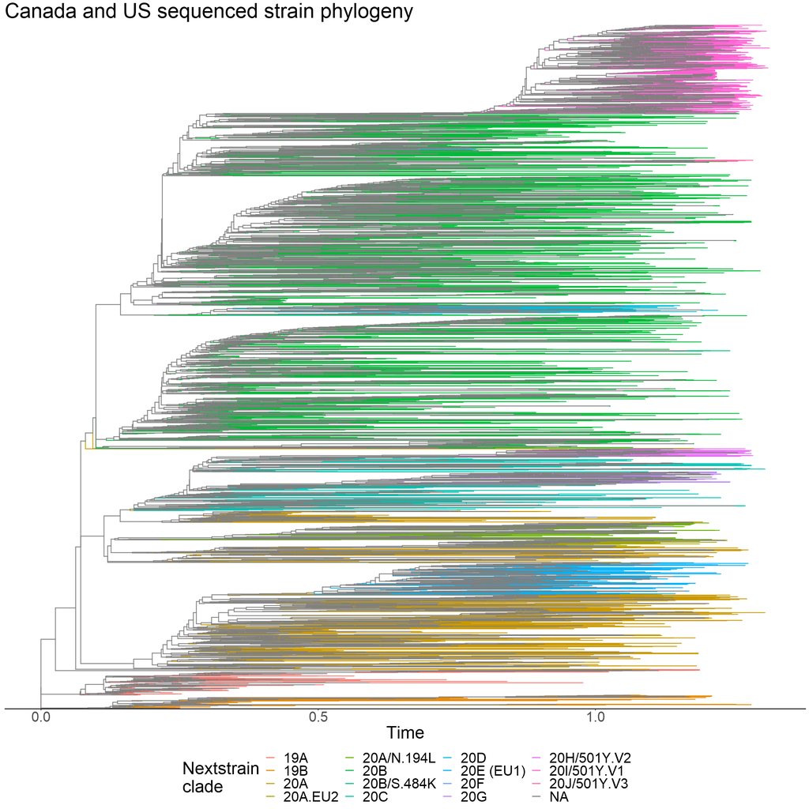

```r
# Adjust our plot window size according to the expected output
options(repr.plot.width=20, repr.plot.height=20)

# Show the entire tree

SC2_variants_time.tree %>%

# 1. Data
ggtree(tr = .) +
    # 2. Aesthetics
    aes(color = emerging_nextstrain) +

    # Themes
    theme_tree2() +
    theme(text = element_text(size = 30),
          legend.position = "bottom") + # Move our legend to the bottom

    # Provide some labels
    labs(x="Time",
         title = "Canada and US sequenced strain phylogeny") +

    # Make our guide lines a little thicker
    guides(colour = guide_legend(title = "Nextstrain\nclade",
                                          override.aes = list(size=2)))
```

## 1.5.0 Filter your tree using `drop.tip()`

Looking at our visualization, there are a lot of tips to display and we've coloured the tree along the branches. Another thing we can see is that there is an "NA" value. This mostly represents the branches of the tree connecting nodes internally since they do not have a specific lineage associated from our data.

As it stands, there's just way too much data here to look at and work with. We can trim that data using the `drop.tip()` function without worrying about how the tree is parsed. Internally, all that pruning will take place within the function. To do this, we'll generate a list of tips we want to *remove* first.

```r
# You can make a list of tips to drop when you're making your ggtree

# Generate a table of tree information to drop
to_drop <-

SC2_metadata.df %>%

# Filter for strains that are not from Canada and are from before 2020-11-01
filter(!(Country == "Canada" &
         `Collection Data` >= as.Date("2020-11-01")
        )) %>%

# Just keep the strain information
pull(Strain)

# Take a look at what we got back
str(to_drop)
```

```
 chr [1:6199] "Wuhan/WH01/2019" "USA/MA1/2020" ...
```

```r
# At the same time make a dataset to keep. You'll use this to update the information in the tree later
to_keep <- SC2_metadata.df %>% filter(!Strain %in% to_drop)

# Which tips are we keeping?
str(to_keep, give.attr = FALSE)
```

```
spc_tbl_ [428 x 24] (S3: spec_tbl_df/tbl_df/tbl/data.frame)
 $ Strain                    : chr [1:428] "Canada/NS-NML-16223/2021" "Canada/NB-NML-3294/2021" "Canada/NS-NML-16211/2021" "Canada/NB-NML-5584/2021" ...
 $ GISAID clade              : chr [1:428] "S" "S" "S" "S" ...
 $ Nextstrain clade          : chr [1:428] "19B" "19B" "19B" "19B" ...
 $ Age                       : num [1:428] 23 25 35 29 61 79 NA NA NA NA ...
 $ Clade                     : chr [1:428] "19B" "19B" "19B" "19B" ...
 $ Country                   : chr [1:428] "Canada" "Canada" "Canada" "Canada" ...
 $ Admin Division            : chr [1:428] "Nova Scotia" "New Brunswick" "Nova Scotia" "New Brunswick" ...
 $ Admin Division of exposure: chr [1:428] "Nova Scotia" "New Brunswick" "Nova Scotia" "New Brunswick" ...
 $ gisaid_epi_isl            : chr [1:428] "EPI_ISL_1055741" "EPI_ISL_961659" "EPI_ISL_1055730" "EPI_ISL_961643" ...
 $ Host                      : chr [1:428] "Human" "Human" "Human" "Human" ...
 $ Originating Lab           : chr [1:428] "QEII Health Sciences Centre" "Hôpital Georges L. Dumont" "QEII Health Sciences Centre" "Hôpital Georges L. Dumont" ...
 $ PANGO lineage             : chr [1:428] "A.2.5" "A.23.1" "A.23.1" "A.23.1" ...
 $ Submission Date           : chr [1:428] "Older" "Older" "Older" "Older" ...
 $ Region                    : chr [1:428] "North America" "North America" "North America" "North America" ...
 $ Region of exposure        : chr [1:428] "North America" "North America" "North America" "North America" ...
 $ Sex                       : chr [1:428] "Male" "Female" "Female" "Male" ...
 $ strain                    : chr [1:428] "Canada/NS-NML-16223/2021" "Canada/NB-NML-3294/2021" "Canada/NS-NML-16211/2021" "Canada/NB-NML-5584/2021" ...
 $ Emerging Nextstrain clade : chr [1:428] "19B" "19B" "19B" "19B" ...
 $ Submitting Lab            : chr [1:428] "National Microbiology Laboratory (NML)" "National Microbiology Laboratory (NML)" "National Microbiology Laboratory (NML)" "National Microbiology Laboratory (NML)" ...
 $ url                       : logi [1:428] NA NA NA NA NA NA ...
 $ Collection Data           : Date[1:428], format: "2021-01-16" "2021-01-02" ...
 $ Author                    : chr [1:428] "Anna Majer et al" "Anna Majer et al" "Anna Majer et al" "Anna Majer et al" ...
 $ Country of exposure       : chr [1:428] NA NA NA NA ...
 $ Location                  : chr [1:428] NA NA NA NA ...
```

## 1.6.0 Update our pruned tree and add some extra `geom_*` layers

The `ggtree` package brings a number of `ggplot2`-compatible geoms to our finger *tips*. We'll spruce up our tree with some tip labels to begin with. We'll accomplish this with the `geom_tiplab()` layer.

| Component type | Layer type | Command | Description |
| --- | --- | --- | --- |
| Tree | Geom | geom_tree | tree structure layer, with multiple layout supported |
| Tree | Geom | geom_treescale | tree branch scale legend |
| Node | Geom | geom_nodepoint | annotate internal nodes with symbolic points |
| Node | Annotation | geom_range | bar layer to present uncertainty of evolutionary inference |
| Node | Annotation | geom_rootpoint | annotate root node with symbolic point |
| Branch | Annotation | geom_label2 | modified version of geom_label, with subsetting supported for labelling branches |
| Branch | Annotation | geom_segment2 | modified version of geom_segment, with subsetting supported |
| Taxa | Geom | geom_point2 | modified version of geom_point, with subsetting supported |
| Taxa | Geom | geom_tippoint | annotate external nodes with symbolic points |
| Taxa | Annotation | geom_taxalink | associate two related taxa by linking them with a curve |
| Taxa | Annotation | geom_text2 | modified version of geom_text, with subsetting supported |
| Taxa | Annotation | geom_tiplab | layer of tip labels |
| Taxa | Annotation | geom_tiplab2 | layer of tip labels for circular layout |
| Clade | Annotation | geom_balance | highlights the two direct descendant clades of an internal node |
| Clade | Annotation | geom_cladelabel | annotate a clade with bar and text label |
| Clade | Annotation | geom_hilight | highlight a clade with rectangle |
| Clade | Annotation | geom_strip | annotate associated taxa with bar and (optional) text label |

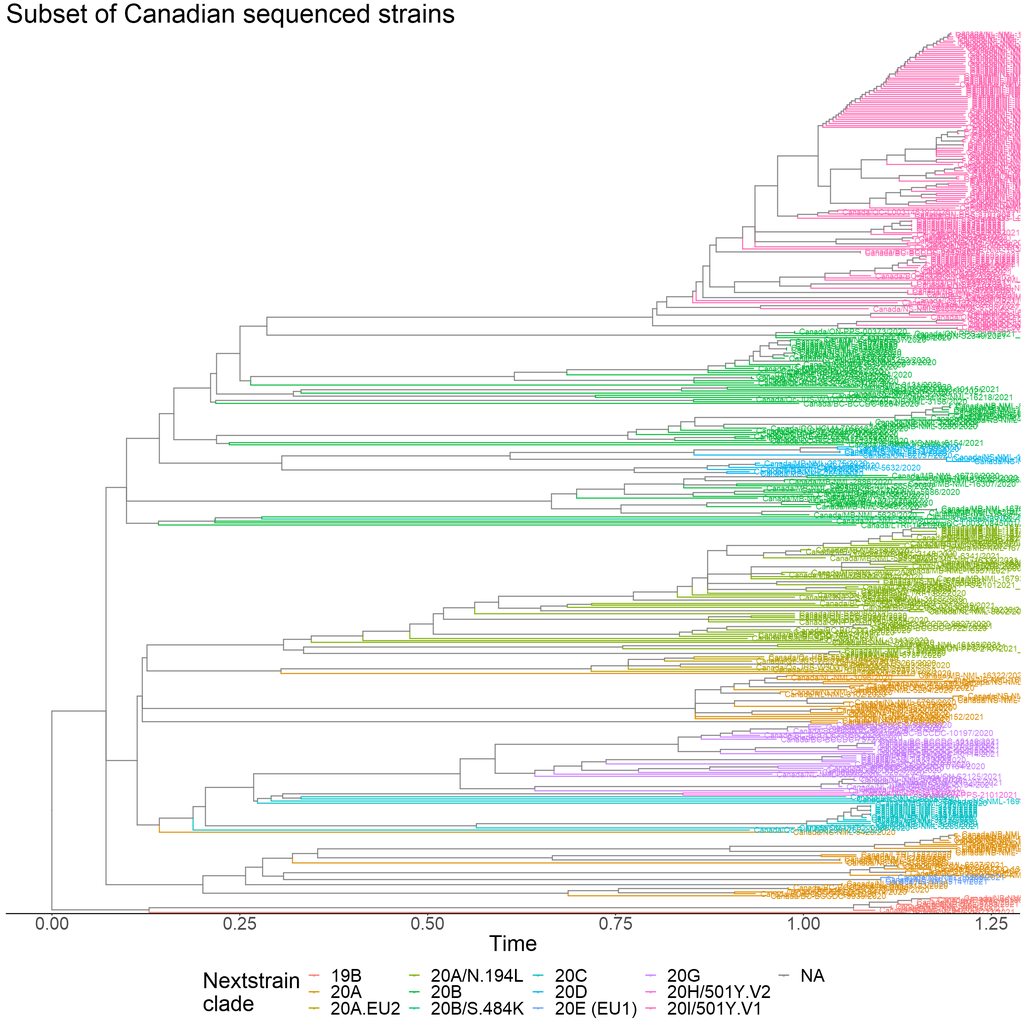

```r
# Show our pruned tree

SC2_variants_time.tree %>%
# drop tips based on our list
drop.tip(., to_drop) %>%

# 1. Data
ggtree(tr = .) + # Need the most recent sampling date
    # 2. Aesthetics
    aes(color = emerging_nextstrain) +

    # Themes
    theme_tree2() +
    theme(text = element_text(size = 30),
          legend.position = "bottom") + # Move our legend to the bottom

    # Provide some labels
    labs(x="Time",
         title = "Subset of Canadian sequenced strains") +

    # Make our guide lines a little thicker
    guides(colour = guide_legend(title = "Nextstrain\nclade",
                                          override.aes = list(size=2))) +

    # 4. Geoms
    ### 1.6.0 Add tips labels to our tree tips
    geom_tiplab()
```

### 1.6.1 Replace labels with points using different geoms

In a tree this packed, you can't really read the tip labels. The data that's most helpful, however, is the colouring. You can replace your labels with points in 3 ways:

- `geom_point()`
- `geom_nodepoint()`
- `geom_tippoint()`

If we use `geom_point()` we can colour/annotate all of the nodes and tips but we already know that there isn't any phylogenetic information associated with our internal nodes. Likewise, `geom_nodepoint()` will allow us to colour the nodes but there isn't any grouping information associated with that.

Therefore we'll use `geom_tippoint()` to colour our tips based on their Nextstrain clade information and we can alter the tip shape to match the province where the strain was sequenced.

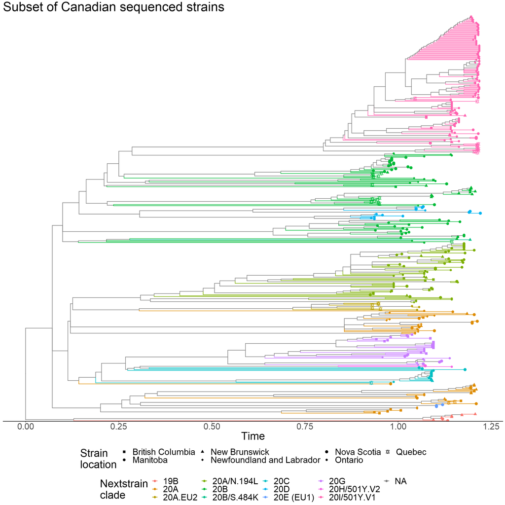

```r
# Show entire tree

SC2_variants_time.tree %>%
drop.tip(., to_drop) %>%

# 1. Data
ggtree(tr = .) + # Need the most recent sampling date
    # 2. Aesthetics
    aes(color = emerging_nextstrain) +

    # Themes
    theme_tree2() +
    theme(text = element_text(size = 30),
          legend.position = "bottom", # Move our legend to the bottom
          legend.box = "vertical") +  # Stack legends vertically

    # Provide some labels
    labs(x="Time",
         title = "Subset of Canadian sequenced strains") +

    # Make our guide lines a little thicker
    guides(colour = guide_legend(title = "Nextstrain\nclade",
                                          override.aes = list(size=2)),
           shape = guide_legend(title = "Strain\nlocation")
          ) +

    # 3. Scaling
    scale_shape_manual(values = c(15:20, 11)) +

    # 4. Geoms
    # Add tips labels to our tree tips
    ### 1.6.1 Change our tip shape by strain_division
    geom_tippoint(aes(shape = strain_division), size = 3)  # Add tips only
```

### 1.6.2 Fix your x-axis with the `mrsd` parameter

As you can see we are working with a time-based axis but it all appears to be on a relative scale and what we'd really like to see is real-world time. In order to do that, we can assign the `mrsd` parameter to the most recent sampling date in our dataset. We'll also set our parameter `as.Date` in order to see the date in a calendar format rather than a decimal-date format.

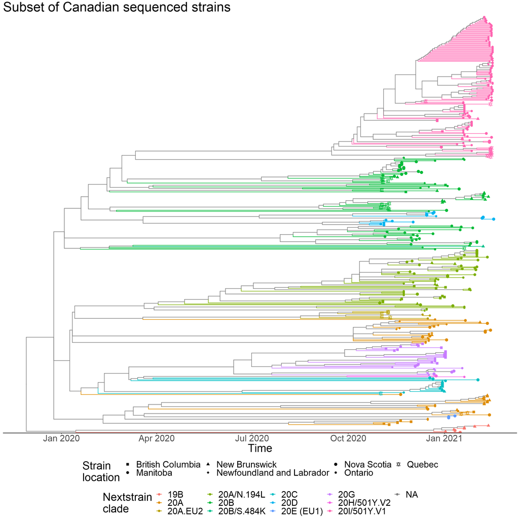

```r
# Show entire tree

SC2_variants_time.tree %>%
drop.tip(., to_drop) %>%

# 1. Data
ggtree(tr = .,
       mrsd = "2021-02-17",    ### 1.6.2 Set the most recent sampling date
       as.Date = TRUE) +       ### 1.6.2 Make sure it's set as a data
    # 2. Aesthetics
    aes(color = emerging_nextstrain) +

    # Themes
    theme_tree2() +
    theme(text = element_text(size = 30),
          legend.position = "bottom", # Move our legend to the bottom
          legend.box = "vertical") +  # Stack legends vertically

    # Provide some labels
    labs(x="Time",
         title = "Subset of Canadian sequenced strains") +

    # Make our guide lines a little thicker
    guides(colour = guide_legend(title = "Nextstrain\nclade",
                                          override.aes = list(size=2)),
           shape = guide_legend(title = "Strain\nlocation")
          ) +

    # 3. Scaling
    scale_shape_manual(values = c(15:20, 11)) +

    # 4. Geoms
    # Add tips labels to our tree tips
    # Change our tip shape by strain_division
    geom_tippoint(aes(shape = strain_division), size = 3)  # Add tips only
```

## 1.7.0 Thin out the tree some more with `viewClade()` and other information functions

Looking at the tree there are still quite a few nodes but we can zoom in on a specific clade using the `viewClade()` function. To accomplish this we need to access the MRCA of a group. At the same time, we should talk about ways to traverse or navigate this tree. Here's where `tidytree` offers up a few additional functions for searching your `tbl_tree`. These take on the form of `function(tbl_tree, node_number)` or `function(tbl_tree, node_label)`

| function | Description |
| --- | --- |
| child() | Find the children of an internal node. |
| parent() | Find the parent node of a tip or other node. |
| offspring() | Find all of the offspring of a node. |
| ancestor() | Find all of the ancestors of a tip or node |
| sibling() | Find the nearest sibling of a tip (or node) |
| MRCA() | Find the most recent common ancestor between two or more nodes |

Let's filter our taxa list a little more searching for variants of the clade 501Y.V1 and 501Y.V2. Then we'll find the MRCA between those tips.

```r
# You can make a list of tips to drop when you're making your ggtree

# Generate a table of tree information to drop
to_view <-

SC2_metadata.df %>%

    # Filter our tip information
    filter(`Emerging Nextstrain clade` %in% c("20I/501Y.V1", "20H/501Y.V2") &
           Country == "Canada" &
           `Collection Data` >= as.Date("2021-02-16")
          ) %>%

    # Just keep the strain names
    pull(Strain)

# What's the list look like?
to_view
```

1. 'Canada/NL-NML-17170/2021'

2. 'Canada/NL-NML-17182/2021'

3. 'Canada/NL-NML-17173/2021'

4. 'Canada/NL-NML-17193/2021'

5. 'Canada/NL-NML-17157/2021'

6. 'Canada/NL-NML-17185/2021'

7. 'Canada/NL-NML-17189/2021'

8. 'Canada/NL-NML-17196/2021'

9. 'Canada/NL-NML-17184/2021'

10. 'Canada/NL-NML-17166/2021'

11. 'Canada/NL-NML-17191/2021'

12. 'Canada/NL-NML-17172/2021'

13. 'Canada/NL-NML-17187/2021'

14. 'Canada/NL-NML-17168/2021'

15. 'Canada/NL-NML-17194/2021'

16. 'Canada/NL-NML-17158/2021'

17. 'Canada/NL-NML-17183/2021'

18. 'Canada/NL-NML-17165/2021'

```r
# Calculate the MRCA from a subset of our tips

to_view_MRCA <-
# Pass along our tree information
SC2_variants_time.tree %>%

# Get rid of the tips we would before (to match the tree we'll plot)
drop.tip(., to_drop) %>%

# Determine the MRCA between the first 4 tips in the list
MRCA(., to_view[1:4])

# What kind of value does MRCA() return?
to_view_MRCA
```

727

```r
# How many offspring does it have?

# Pass along our tree information
SC2_variants_time.tree %>%

    # Drop our original set of tips
    drop.tip(., to_drop) %>%
    # make a tibble so we can see all the relevant information
    as_tibble() %>%
    # Find the offspring of a specific node
    offspring(., to_view_MRCA) %>%
    # Convert to a tree
    as.treedata() %>%
    str()
```

```
Formal class 'treedata' [package "tidytree"] with 11 slots
  ..@ file       : chr(0)
  ..@ treetext   : chr(0)
  ..@ phylo      :List of 5
  .. ..$ edge       : int [1:71, 1:2] 728 730 731 732 732 734 735 735 736 737 ...
  .. .. ..- attr(*, "dimnames")=List of 2
  .. .. .. ..$ : NULL
  .. .. .. ..$ : chr [1:2] "parent" "node"
  .. ..$ edge.length: num [1:71] 0.1136 0.067 0.0521 0.0306 0.0333 ...
  .. ..$ tip.label  : chr [1:39] "Canada/NL-NML-16819/2021" "Canada/NL-NML-16824/2021" "Canada/NL-NML-17178/2021" "Canada/NL-NML-16829/2021" ...
  .. ..$ node.label : chr [1:32] "NODE_0006538" "NODE_0006539" "NODE_0006540" "NODE_0006541" ...
  .. ..$ Nnode      : int 32
  .. ..- attr(*, "class")= chr "phylo"
  ..@ data       : tibble [71 x 8] (S3: tbl_df/tbl/data.frame)
  .. ..$ node               : int [1:71] 323 324 325 326 327 328 329 330 331 332 ...
  .. ..$ GISAID             : chr [1:71] "GRY" "GRY" "GRY" "GRY" ...
  .. ..$ emerging_nextstrain: chr [1:71] "20I/501Y.V1" "20I/501Y.V1" "20I/501Y.V1" "20I/501Y.V1" ...
  .. ..$ PANGO              : chr [1:71] "B.1.1.7" "B.1.1.7" "B.1.1.7" "B.1.1.7" ...
  .. ..$ strain_country     : chr [1:71] "Canada" "Canada" "Canada" "Canada" ...
  .. ..$ strain_division    : chr [1:71] "Newfoundland and Labrador" "Newfoundland and Labrador" "Newfoundland and Labrador" "Newfoundland and Labrador" ...
  .. ..$ strain_date        : Date[1:71], format: "2021-02-10" "2021-02-12" ...
  .. ..$ Age                : num [1:71] 47 16 26 62 60 45 19 45 35 31 ...
  ..@ extraInfo  : tibble [0 x 0] (S3: tbl_df/tbl/data.frame)
 Named list()
  ..@ tip_seq    : NULL
  ..@ anc_seq    : NULL
  ..@ seq_type   : chr(0)
  ..@ tipseq_file: chr(0)
  ..@ ancseq_file: chr(0)
  ..@ info       : list()
```

### 1.7.1 Pass a `ggplot2` object to `viewClade()`

We see that our chosen MRCA node (727) has 39 children based on the number of tip labels in our `treedata` object. We can also now use this MRCA to determine the specific clade we can see on the tree but this will still be quite large. To view this particular clade, we build our plot as before, and then zoom into it afterwards with the `viewClade()` function.

Unfortunately, we'll have to ditch our date scale and revert to a decimal-date. If you're not using a calendar-based date, it's not a problem at all. If we look carefully at the data, we'll see that the internal nodes have an NA-value. If you were *industrious enough*, you could use the branch lengths to traverse the tree and calculate dates for all the internal nodes as well. This would likely solve the issue.

Let's drop the tip names back in there too.

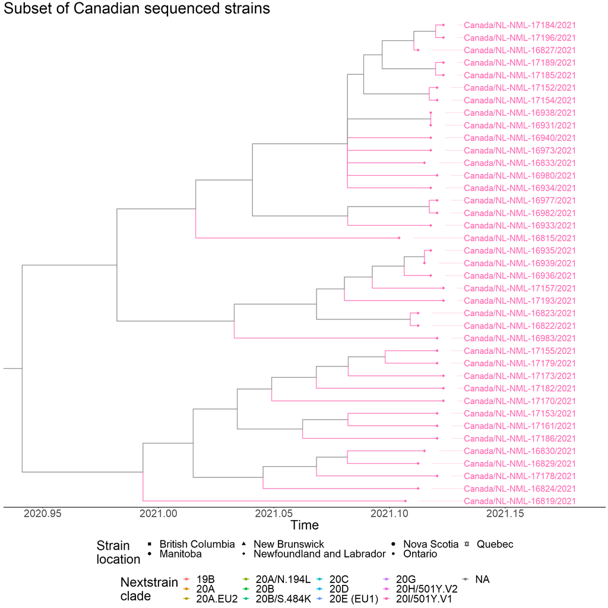

```r
# Show a small clade of the tree

tree.plot <-

SC2_variants_time.tree %>%
# From our tree, drop the Non-Canadian tips
drop.tip(., to_drop) %>%

# 1. Data
ggtree(tr = ., mrsd = "2021-02-16") + # Need the most recent sampling date
    # 2. Aesthetics
    aes(color = emerging_nextstrain) +

    # Themes
    theme_tree2() +
    theme(text = element_text(size = 30),
          legend.position = "bottom", # Move our legend to the bottom
          legend.box = "vertical") +  # Stack legends vertically

    # Provide some labels
    labs(x="Time",
         title = "Subset of Canadian sequenced strains") +

    # Make our guide lines a little thicker
    guides(colour = guide_legend(title = "Nextstrain\nclade",
                                          override.aes = list(size=2)),
           shape = guide_legend(title = "Strain\nlocation")
          ) +

    # 3. Scaling
    scale_shape_manual(values = c(15:20, 11)) +

    # 4. Geoms
    geom_tiplab(size = 7, align=TRUE) + # Add labels in and right-align them

    # Add tips labels to our tree tips
    # Change our tip shape by strain_division
    geom_tippoint(aes(shape = strain_division), size = 3)  # Add tips only

### 1.7.1 View the clade we made using the same MRCA call we already used.
viewClade(tree.plot, MRCA(tree.plot, to_view[1:5]))
```

## 1.8.0 Make a new subplot with information from across all clades

So we've looked at a few ways to subset and plot our phylogenetic tree. We'll do a quick aside to create a more curated list of tips with representation from across multiple clades. We'll use this as the base tree for our next few graphs so that we can really see the power of using additional information from our `treedata` object.

```r
# Here's our representative list of tips from multiple clades

curated_tips <-
c('Wuhan/WH01/2019',
'Canada/ON_ON-VIDO-01-2/2020',
'Canada/ON_VIDO-01/2020',
'Canada/BC_37_0-2/2020',
'Canada/BC_69243/2020',
'Canada/QC-CHUM-2008003956A/2020',
'Canada/NL-NML-1387/2020',
'Canada/MB-NML-808/2020',
'Canada/NB-NML-16967/2021',
'Canada/BC_6129127/2020',
'Canada/AB-97776/2020',
'Canada/AB-12948/2020',
'Canada/BC-BCCDC-3564/2020',
'Canada/ON-S67/2020',
'Canada/AB-65233/2020',
'Canada/MB-NML-1057/2020',
'Canada/ON-UHTC-0366/2020',
'Canada/NS-NML-16218/2021',
'Canada/NB-NML-16966/2021',
'Canada/NS_13/2020',
'Canada/Qc-CHUM-2019203856A/2020',
'Canada/NB-NML-3272/2020',
'Canada/ON-UHTC-0267/2020',
'Canada/MB-NML-1037/2020',
'Canada/NS-NML-5213/2020',
'Canada/NS-NML-5141/2021',
'Canada/NS-NML-5140/2021',
'Canada/NS-NML-16208/2021',
'Canada/BC-BCCDC-7012/2020',
'Canada/ON-LTRI-1372/2020',
'Canada/BC-BCCDC-9736/2021',
'Canada/ON-S2125/2021',
'Canada/NS-NML-5181/2020',
'Canada/ON-PPS-21012021_0269/2021',
'Canada/QC-L00314539/2020',
'Canada/NS-NML-16238/2021',
'Canada/NL-NML-16822/2021',
'Canada/QC-L00324589001/2021',
'Canada/NL-NML-17194/2021')
```

```r
# Make a new list of tips to drop
curated_drop_list <-
    SC2_metadata.df %>%

    # filter the opposite of our tip labels
    filter(!(Strain %in% curated_tips)) %>%
    # Only keep the strain information for what we want to drop
    pull(Strain)
```

```r
# Drop tips from our tree and save it as curated_tree_info.df
curated_tree_info.df <-

    # Pass along our original tree
    SC2_variants_time.tree %>%

    # Drop the tips we created
    drop.tip(., curated_drop_list) %>%

    # Convert to a tibble
    as_tibble() %>%

    # Rename our column information
    rename(Clade = emerging_nextstrain, Province = strain_division) %>%

    mutate(Age = replace_na(Age, replace = 0)) %>%

    # Convert this to a data frame
    as.data.frame()

# Set the rownames from the label information
rownames(curated_tree_info.df) <- curated_tree_info.df$label

# Let's view the tree
str(curated_tree_info.df)
```

```
'data.frame':	72 obs. of  11 variables:
 $ parent        : int  40 42 42 44 44 45 45 46 46 48 ...
 $ node          : int  1 2 3 4 5 6 7 8 9 10 ...
 $ branch.length : num  0.0757 0.0077 0.0077 0.1439 0.0729 ...
 $ label         : chr  "Wuhan/WH01/2019" "Canada/ON_ON-VIDO-01-2/2020" "Canada/ON_VIDO-01/2020" "Canada/MB-NML-808/2020" ...
 $ GISAID        : chr  "L" "L" "L" "S" ...
 $ Clade         : chr  "19A" "19A" "19A" "19B" ...
 $ PANGO         : chr  "B" "B" "B" "A.1" ...
 $ strain_country: chr  "Asia" "Canada" "Canada" "Canada" ...
 $ Province      : chr  "Asia" "Ontario" "Ontario" "Manitoba" ...
 $ strain_date   : Date, format: "2019-12-26" "2020-01-23" ...
 $ Age           : num  44 0 0 0 27 59 0 43 35 53 ...
```

## 1.9.0 Convert your tree style with the `layout` parameter

So we've only been working with a rectangular tree (horizontal layout) thus far but as we mentioned at the beginning there are actually a number of different layouts we can use. Our goal now is to make a sort of sunburst plot now using a circular layout that we'll add visual categorical information to in a ring pattern.

First, we'll start with the circular version. We'll colour our tips by the province where the case or data was generated and label them by the Nextstrain clade information.

[figure not shown]

```r
# Show our curated tree in a circular format

tree.plot <-

SC2_variants_time.tree %>%
drop.tip(., curated_drop_list)  %>%

# 1. Data
ggtree(., layout = "circular", ### 1.9.0 Set the layout to circular
    mrsd = "2021-02-17") + # Need the most recent sampling date
    # 2. Aesthetics

    # Themes
    theme(text = element_text(size = 30),
          legend.position = "bottom") +
    labs(title = "Canada and US sequenced strain phylogeny",
         colour = "Province") +

    scale_colour_viridis_d(option = "plasma") + # This seems to literally kill the kernel!

    # 4. Geoms
    geom_tippoint(aes(colour = strain_division), size = 5) +

    ### 1.9.0 set the tip labels
    geom_tiplab(aes(label = emerging_nextstrain), size = 8)

# View our tree
tree.plot
```

## 1.10.0 Use `gheatmap()` layer to add information to your plot

Now that we have our basic circular tree, we can use the information from `curated_tree_info.df` to visualize additional data on our tree. In order to use the `gheatmap` layer properly, we must pass it our original tree plot, along with a new dataframe (or vector) that holds the information we want to add. It should use the rownames from the data frame to help match up to the tips in our tree.

We'll drop the tip labels from our tree in favour of the heatmap we'll add. By adding layers of hierarchical data, this creates what is known as a **Sunburst** plot.

The gheatmap() layer takes some of the following parameters:

- `p`: the tree plot we want to modify.
- `data`: the data used to modify the tree plot `p`.
- `offset`: determines the offset of the heatmap relative to the tree.
- `width`: determines the total width of the heatmaps compared to the tree
- `colnames_angle`: determines the angle of the text for the heatmap.
- `font.size`: sets the font size for the heatmap portion of the tree.

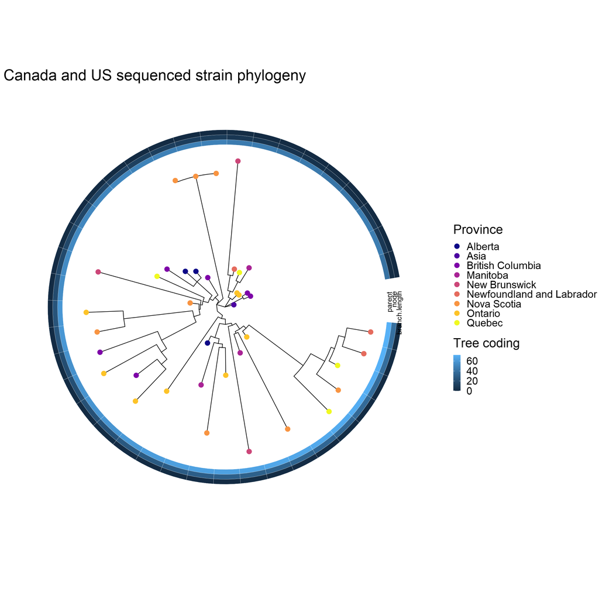

```r
# Show our curated tree in a circular format

tree.plot <-

SC2_variants_time.tree %>%
drop.tip(., curated_drop_list)  %>%

# 1. Data
ggtree(., layout = "circular", mrsd = "2021-02-17") + # Need the most recent sampling date
    # 2. Aesthetics

    # Themes
    theme(text = element_text(size = 30),
          legend.position = "bottom") +
    labs(title = "Canada and US sequenced strain phylogeny",
         colour = "Province") +

    scale_colour_viridis_d(option = "plasma") +

    # 4. Geoms
    geom_tippoint(aes(colour = strain_division), size = 5) # Add tips only

### 1.10.0 Add a circular heatmap with gheatmap()
tree.plot <- gheatmap(tree.plot, curated_tree_info.df %>% select(parent, node, branch.length),
                      offset = 0.1, width = 0.1,
                      colnames_angle = 90, font.size = 6, hjust = 1) +
    scale_fill_continuous(name = "Tree coding")


tree.plot
```